# *Batrachochytrium salamandrivorans* prevalence is associated positively with host density and negatively with host richness across European amphibian communities

- Show All Code
- Hide All Code
- View Source

Author

Alexis Korotasz

Published

August 9, 2024

## Abstract

1. Amphibians are one of the most threatened vertebrate taxa on the planet and a prominent driver of these declines is chytridiomycosis, a fungal disease caused by *Batrachochytrium dendrobatidis* (Bd) and, more recently, *Batrachochytrium salamandrivorans* (Bsal). Since its discovery, the known range of Bsal has rapidly expanded, devastating salamander populations across Europe.
2. Research thus far has shown that temperature and moisture play a major role in the persistence of Bsal in the environment and that susceptibility to Bsal varies among species. However, little is known about host community composition and richness as drivers of Bsal prevalence.
3. To investigate how community structure (i.e., host abundance and richness) affects Bsal prevalence, we compiled and analyzed publicly available data on the swabbing of **2,909 amphibians** from **45 Bsal positive sites** across Europe comprised of some combination of **14 unique species**.
4. We show that the amphibian-Bsal system meets several pre-requisites for a dilution effect, which describes a negative host biodiversity-disease relationship. Namely, there is variation in host competence and, despite Bsal being associated with host declines, the most abundant species were the least resistant and most competent hosts of Bsal. On average across all communities, Bsal prevalence was associated positively with host density and negatively with host richness, supporting density-dependent transmission and a dilution effect. Additionally, a dilution effect was observed for fire salamanders (*Salamandra salamandra*), the species experiencing the greatest declines from Bsal in Europe. However, for fire salamanders, Bsal prevalence was associated negatively with host density, presumably because Bsal is causing population declines in this species.
5. These results suggest that conserving salamander species could reduce Bsal transmission and Bsal-induced salamander population declines.

**Keywords:** amphibian, Bsal, chytridiomycosis, dilution effect, disease ecology, salamander

## Data exploration

### Checking for outliers

**code </>**

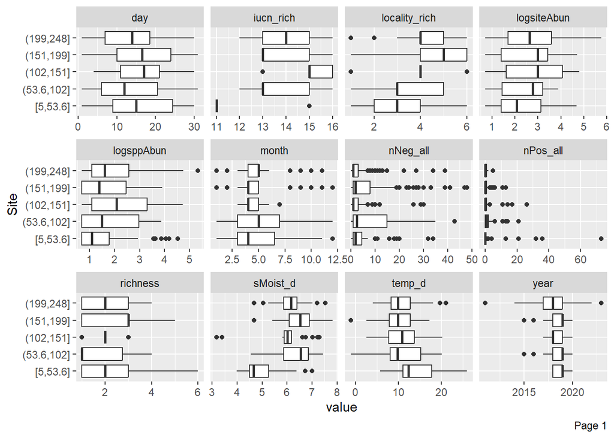

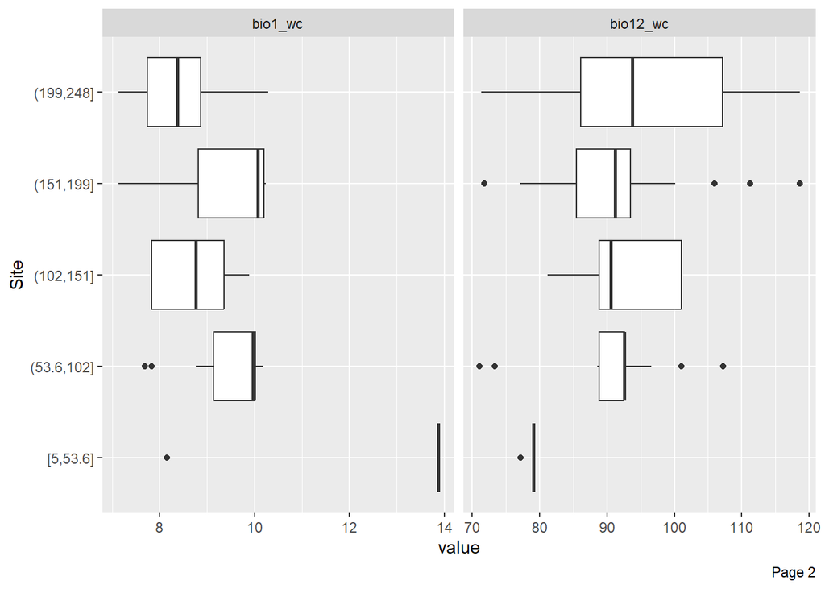

```r
posSites <- dcbind_all %>%
  filter(posSite == "1")

## Reduce data size to capture most important variables
posSites_reduced <- posSites %>%
  separate_wider_delim(., cols = date, delim = "-", names = c("year", "month", "day")) %>%
  mutate(year = as.numeric(year),
         month = as.numeric(month),
         day = as.numeric(day)) %>%
  subset(., select = c(Site, year, month, day, richness, iucn_rich, locality_rich, logsppAbun, logsiteAbun, nPos_all, nNeg_all, temp_d, sMoist_d, bio1_wc, bio12_wc))

## Call boxplot function to check for outliers
DataExplorer::plot_boxplot(posSites_reduced, by = "Site")
```

**code </>**

```r
## Look closer at 'nPos_all'
rstatix::identify_outliers(posSites_reduced, nPos_all) # Be aware of the extreme outlier -- not going to do anything about it now
```

```
# A tibble: 34 × 17
    Site  year month   day richness iucn_rich locality_rich logsppAbun
   <int> <dbl> <dbl> <dbl>    <int>     <int>         <int>      <dbl>
 1    20  2018     5    10        3        11             3       4.53
 2    20  2019     3    13        3        11             3       2.71
 3    20  2019     4     2        4        11             4       3.87
 4    20  2019     4    11        2        11             2       4.17
 5    20  2019     4    25        2        11             2       4.04
 6    20  2019     5     3        2        11             2       3.64
 7    76  2015    11    18        1        15             1       3.14
 8    78  2019     3     6        3        13             3       2.83
 9    85  2019     2    28        1        13             3       3.04
10    85  2019     3     1        1        13             3       3.61
# ℹ 24 more rows
# ℹ 9 more variables: logsiteAbun <dbl>, nPos_all <int>, nNeg_all <int>,
#   temp_d <dbl>, sMoist_d <dbl>, bio1_wc <dbl>, bio12_wc <dbl>,
#   is.outlier <lgl>, is.extreme <lgl>
```

### Static Maps

Europe polygons were re-projected to EPSG:27704 (WGS84/Equi7 Europe) for mapping purposes. These projections were made as a part of [a larger project](https://github.com/TUW-GEO/Equi7Grid)/[paper](https://doi.org/10.1016/j.cageo.2014.07.005) to optimize handling remote-sensing data, with each continent having their own centroid.

[figure not shown]